# Tasa de desempleo por promedio de escolaridad y salario mínimo

Domínguez Ávila Luis Antonio Escobar González Jennifer Cristina Gutiérrez Ramírez Miguel Ángel López Ramos Luisa Cassandra

2023-10-2

Selección del tema

1. Selecciona un tema de tu interés al que se pueda aplicar un modelo de regresión lineal

Tasa de desempleo por promedio de escolaridad y salario mínimo

2. Justifica brevemente la relevancia del tema y la herramienta que utilizarás (modelo de regresión múltiple). Busca antecedentes en la literatura especializada

El tema “Tasa de desempleo por promedio de escolaridad y salario mínimo” es relevante porque permite analizar la relación entre el nivel educativo de la población y sus oportunidades laborales, así como el impacto del salario mínimo en el mercado de trabajo. Este tema es de interés para los economistas, los sociólogos, los políticos y los ciudadanos en general, ya que afecta el bienestar social, el crecimiento económico y la distribución del ingreso.

Para este proyecto utilizamos las bases de datos del INEGI como medio para obtener los datos a utilizar en el proyecto, y el lenguaje R para realizar los modelos de regresión lineal.

3. Busca los datos que sean más adecuados. No olvides citar la fuente.

Recolectamos los datos de escolaridad, salario mínimo y desempleo del INEGI, entre los años 2000 y 2020.

4. Organiza los datos en una tabla para RStudio.

```r
tabla<-readxl::read_xlsx("BASE.xlsx")
tabla
```

```
## # A tibble: 21 × 4
##      AÑO escolaridad salario desempleo
##    <dbl>       <dbl>   <dbl>     <dbl>
##  1  2000        7.56    32.2    0.0258
##  2  2001        7.68    38.0    0.027
##  3  2002        7.8     40.8    0.0295
##  4  2003        7.93    42.6    0.034
##  5  2004        8.04    43.7    0.0391
##  6  2005        8.14    45.1    0.0349
##  7  2006        8.26    47.9    0.0353
##  8  2007        8.36    49.4    0.0362
##  9  2008        8.46    51.4    0.0388
## 10  2009        8.56    53.7    0.0533
## # … with 11 more rows
```

5. Describe todas las variables que utilizarás, los nombres que utilizarás, las unidades, la fuente de dónde las obtuviste.
- Tasa de desempleo: esta será nuestra variable dependiente. La usaremos para ver qué tanto influye el promedio de escolaridad y el salario mínimo en el desempleo de nuestro país.
- Promedio de escolaridad: una de nuestras variables independientes. Nos dice cuántos años de escolaridad en promedio cursa un mexicano.
- Salario mínimo: nuestra segunda variable independiente. Nos dice el salario mínimo para una jornada de 8 horas.

Estimación de parámetros, inferencia y especificación del modelo.

1. Desarrolla un modelo de regresión lineal múltiple que estime una variable numérica, a través de variables explicativas.

```r
tabla3 <- select(tabla,escolaridad,salario,desempleo)
modelo2<-lm(desempleo~escolaridad+salario,data=tabla3)
summary(modelo2)
```

```
##
## Call:
## lm(formula = desempleo ~ escolaridad + salario, data = tabla3)
##
## Residuals:
##       Min        1Q    Median        3Q       Max
## -0.011408 -0.003813 -0.001462  0.003758  0.010698
##
## Coefficients:
##               Estimate Std. Error t value Pr(>|t|)
## (Intercept) -0.1515066  0.0454772  -3.331 0.003714 **
## escolaridad  0.0270105  0.0065999   4.093 0.000683 ***
## salario     -0.0006907  0.0002055  -3.360 0.003484 **
## ---
## Signif. codes:  0 '***' 0.001 '**' 0.01 '*' 0.05 '.' 0.1 ' ' 1
##
## Residual standard error: 0.006259 on 18 degrees of freedom
## Multiple R-squared:  0.5105, Adjusted R-squared:  0.4561
## F-statistic: 9.386 on 2 and 18 DF,  p-value: 0.001613
```

2. Calcula los siguientes parámetros: $\beta_1,\beta_2,...,\beta_k$. Calcula sus intervalos de confianza.

```r
summary(modelo2)$coefficients[,"Estimate"]
```

```
##   (Intercept)   escolaridad       salario
## -0.1515065972  0.0270104827 -0.0006906555
```

```r
confint(modelo2)
```

```
##                   2.5 %        97.5 %
## (Intercept) -0.24705073 -0.0559624653
## escolaridad  0.01314456  0.0408764076
## salario     -0.00112246 -0.0002588514
```

3. Realiza una prueba de hipótesis para la significancia general del modelo

```r
f <- qf(1-0.05,df1=21-3,df2=3-1)
f
```

```
## [1] 19.44022
```

```r
summary(modelo2)$fstatistic[1]
```

```
##    value
## 9.386448
```

4. Realiza una prueba de hipótesis para la significancia de cada coeficiente $\beta_i$

```r
t<-qt(1-0.05 / 2,df=21-3)
t
```

```
## [1] 2.100922
```

```r
summary(modelo2)$coefficients[,"t value"]
```

```
## (Intercept) escolaridad     salario
##   -3.331482    4.092545   -3.360351
```

La escolaridad y el salario por si solos si son significativos y nos dan evidencia suficiente para rechazar la hipótesis nula $H_0$.

5. Elimina algunas variables y compara el modelo restringido contra el modelo no restringido

```r
tabla4 <- select(tabla,salario,desempleo)
modelo2<-lm(desempleo~salario,data=tabla4)
summary(modelo2)
```

```
##
## Call:
## lm(formula = desempleo ~ salario, data = tabla4)
##
## Residuals:
##       Min        1Q    Median        3Q       Max
## -0.011162 -0.007632 -0.002266  0.008234  0.014252
##
## Coefficients:
##              Estimate Std. Error t value Pr(>|t|)
## (Intercept) 3.372e-02  6.009e-03   5.612 2.06e-05 ***
## salario     9.989e-05  9.495e-05   1.052    0.306
## ---
## Signif. codes:  0 '***' 0.001 '**' 0.01 '*' 0.05 '.' 0.1 ' ' 1
##
## Residual standard error: 0.008465 on 19 degrees of freedom
## Multiple R-squared:  0.05504,    Adjusted R-squared:  0.005305
## F-statistic: 1.107 on 1 and 19 DF,  p-value: 0.306
```

```r
f <- qf(1-0.05,df1=21-3,df2=3-1)
f
```

```
## [1] 19.44022
```

```r
rnR<- .5105
rR<- 0.05504
# summary(modelo2)$fstatistic[1]
fT<- (rnR-rR)/(1-rnR)*(18/1)
fT
```

```
## [1] 16.74827
```

Interpretación y conclusiones

1. Da una interpretación de cada uno de los coeficientes numéricos que encontraste en la segunda parte.

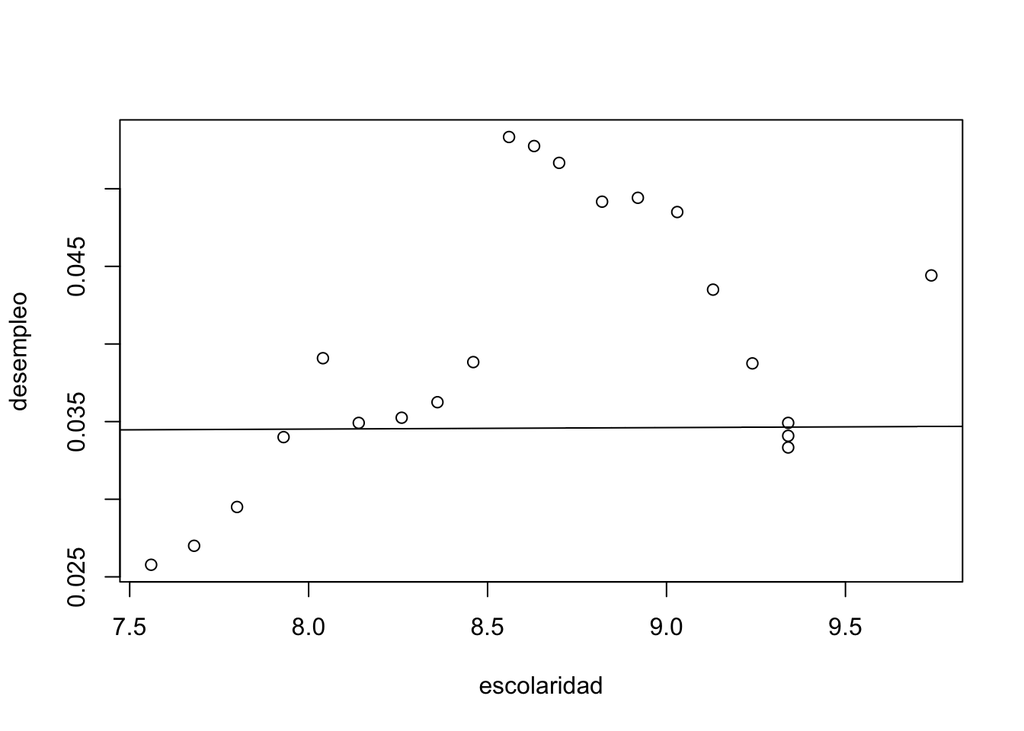

```r
plot(desempleo~escolaridad,data=tabla3)
# modelo1<-lm(Y~X,data=tabla2)
abline(modelo2)
```

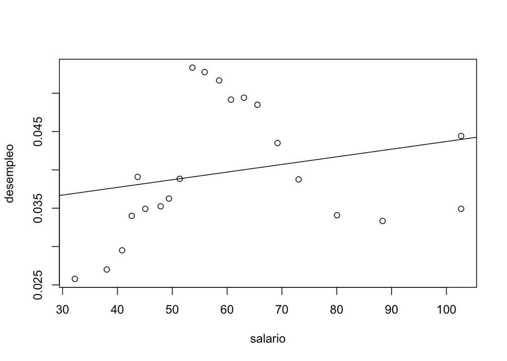

```r
plot(desempleo~salario,data=tabla3)
abline(modelo2)
```

2. Realiza una predicción para un valor de $X_1,X_2,...,X_k$ que no esté en tu muestra (pero que esté cerca de los valores) para predecir el valor de $\hat{Y}_i$

```r
alfa <- -0.1515065972
beta <- 0.0270104827
beta2 <- -0.0006906555
y =alfa+beta*(11)+beta2*(200)
y
```

```
## [1] 0.007477612
```

Calculamos $\hat{Y}_i$ asignando una escolaridad de 11 años y un salario mínimo de $200. Esto nos dice que la tasa de desempleo sería de 0.75%

4. Incluye la bibliografía que hayas utilizado
- INEGI (2021) Grado promedio de escolaridad de la población de 15 y más años por entidad federativa según sexo 2000-2020. (p.1) Estados Unidos Mexicanos: INEGI
- Comisión Nacional de los Salarios Mínimos. (2022). Tabla de Salarios Mínimos Generales y Profesionales por Áreas Geográficas. Recuperado de gob.mx
- Datosmacro.com. (2023). Desempleo de México 2023. Recuperado el 21 de Noviembre de 2023, de https://datosmacro.expansion.com/paro/mexico?sc=LAB-
- SEP. Sistema de indicadores educativos (INDISEP) . Disponible en: http://www.snie.sep.gob.mx/indicadores_x_entidad_feder ativa.html. Fecha de consulta: septiembre de 2017